# STA_6543_Assignment_2

### 9.(c) Use the lm() function to perform a multiple linear regression with mpg as the response and all other variables except name as the predictors. Use the summary() function to print the results.

```r
auto.model <- lm(mpg ~ . -name, data = Auto)
summary(auto.model)
```

```
##
## Call:
## lm(formula = mpg ~ . - name, data = Auto)
##
## Residuals:
##     Min      1Q  Median      3Q     Max
## -9.5903 -2.1565 -0.1169  1.8690 13.0604
##
## Coefficients:
##                Estimate Std. Error t value Pr(>|t|)
## (Intercept)  -17.218435   4.644294  -3.707  0.00024 ***
## cylinders     -0.493376   0.323282  -1.526  0.12780
## displacement   0.019896   0.007515   2.647  0.00844 **
## horsepower    -0.016951   0.013787  -1.230  0.21963
## weight        -0.006474   0.000652  -9.929  < 2e-16 ***
## acceleration   0.080576   0.098845   0.815  0.41548
## year           0.750773   0.050973  14.729  < 2e-16 ***
## origin         1.426141   0.278136   5.127 4.67e-07 ***
## ---
## Signif. codes:  0 '***' 0.001 '**' 0.01 '*' 0.05 '.' 0.1 ' ' 1
##
## Residual standard error: 3.328 on 384 degrees of freedom
## Multiple R-squared:  0.8215, Adjusted R-squared:  0.8182
## F-statistic: 252.4 on 7 and 384 DF,  p-value: < 2.2e-16
```

### (c) ii. Which predictors appear to have a statistically signifcant relationship to the response?

There are 4 predictors that have a relationship with the response variable, mpg:  
- With every one unit increase of displacement we can notice an increase in the response variable by 0.019896 units.  
- With every one unit increase of weight we can notice an decrease in the response variable by 0.006474 units.  
- With every one unit increase of year we can notice an increase in the response variable by 0.750773 units.  
- With every one unit increase of origin we can notice an increase in the response variable by 1.426141 units.

### (c) iii. What does the coefficient for the year variable suggest?

The coefficient for the year variable suggests that newer cars have better gas mileage than older cars.

### 9.(d) Use the plot() function to produce diagnostic plots of the linear regression fit. Comment on any problems you see with the fit. Do the residual plots suggest any unusually large outliers? Does the leverage plot identify any observations with unusually high leverage?

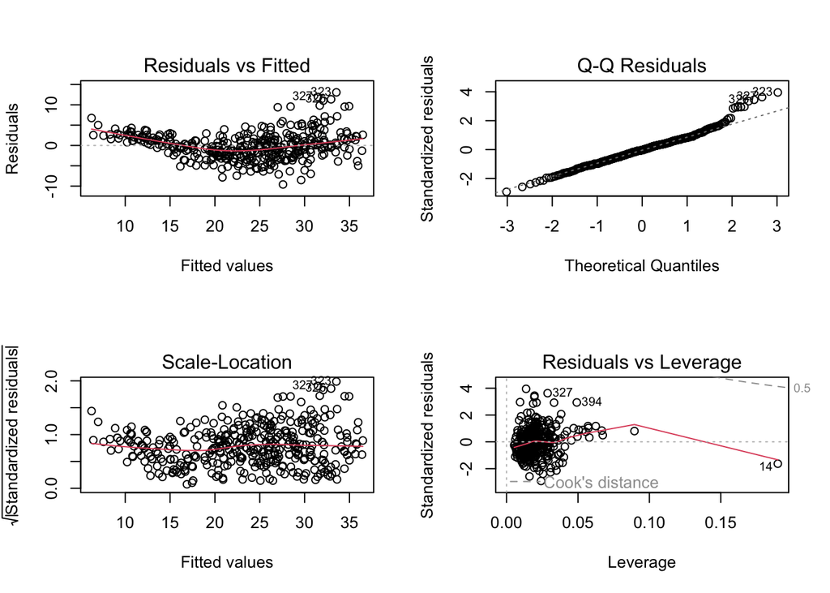

```r
par(mfrow=c(2,2)) # Change the panel layout to 2 x 2
plot(auto.model)
```

### 9.(e) Use the * and : symbols to fit linear regression models with interaction effects. Do any interactions appear to be statistically signifcant?

```r
auto2.model <- lm(mpg ~ displacement * weight * year * origin, data = Auto)
summary(auto2.model)
```

```
##
## Call:
## lm(formula = mpg ~ displacement * weight * year * origin, data = Auto)
##
## Residuals:
##      Min       1Q   Median       3Q      Max
## -10.2148  -1.5712  -0.0295   1.3200  14.3708
##
## Coefficients:
##                                   Estimate Std. Error t value Pr(>|t|)
## (Intercept)                     -1.799e+02  1.174e+02  -1.532   0.1262
## displacement                    -1.019e+00  1.047e+00  -0.973   0.3312
## weight                           8.198e-02  5.106e-02   1.605   0.1092
## year                             3.017e+00  1.540e+00   1.959   0.0508 .
## origin                           1.984e+01  9.933e+01   0.200   0.8418
## displacement:weight              2.297e-04  3.996e-04   0.575   0.5656
## displacement:year                1.249e-02  1.371e-02   0.911   0.3629
## weight:year                     -1.177e-03  6.687e-04  -1.760   0.0793 .
## displacement:origin              1.421e+00  1.002e+00   1.417   0.1572
## weight:origin                   -3.674e-02  4.435e-02  -0.828   0.4080
## year:origin                     -2.073e-01  1.297e+00  -0.160   0.8731
## displacement:weight:year        -2.856e-06  5.197e-06  -0.550   0.5830
## displacement:weight:origin      -3.598e-04  3.932e-04  -0.915   0.3608
## displacement:year:origin        -1.874e-02  1.307e-02  -1.434   0.1524
## weight:year:origin               4.531e-04  5.779e-04   0.784   0.4335
## displacement:weight:year:origin  4.824e-06  5.106e-06   0.945   0.3454
## ---
## Signif. codes:  0 '***' 0.001 '**' 0.01 '*' 0.05 '.' 0.1 ' ' 1
##
## Residual standard error: 2.901 on 376 degrees of freedom
## Multiple R-squared:  0.8672, Adjusted R-squared:  0.8619
## F-statistic: 163.6 on 15 and 376 DF,  p-value: < 2.2e-16
```

```r
auto3.model <- lm(mpg ~ displacement * weight * cylinders * origin, data = Auto)
summary(auto3.model)
```

```
##
## Call:
## lm(formula = mpg ~ displacement * weight * cylinders * origin,
##     data = Auto)
##
## Residuals:
##     Min      1Q  Median      3Q     Max
## -9.6298 -2.4463 -0.3365  1.7266 18.6207
##
## Coefficients:
##                                        Estimate Std. Error t value Pr(>|t|)
## (Intercept)                           1.758e+02  7.391e+01   2.379   0.0178 *
## displacement                         -7.982e-01  5.128e-01  -1.557   0.1204
## weight                               -4.327e-02  2.975e-02  -1.454   0.1467
## cylinders                            -3.555e+01  1.757e+01  -2.024   0.0437 *
## origin                               -1.258e+02  6.952e+01  -1.810   0.0711 .
## displacement:weight                   2.160e-04  1.995e-04   1.083   0.2795
## displacement:cylinders                2.016e-01  1.148e-01   1.756   0.0798 .
## weight:cylinders                      1.106e-02  6.983e-03   1.583   0.1142
## displacement:origin                   6.852e-01  4.855e-01   1.411   0.1590
## weight:origin                         3.854e-02  2.831e-02   1.361   0.1743
## cylinders:origin                      3.512e+01  1.690e+01   2.078   0.0384 *
## displacement:weight:cylinders        -6.208e-05  4.513e-05  -1.376   0.1698
## displacement:weight:origin           -2.008e-04  1.938e-04  -1.036   0.3009
## displacement:cylinders:origin        -1.943e-01  1.129e-01  -1.722   0.0860 .
## weight:cylinders:origin              -1.137e-02  6.838e-03  -1.662   0.0973 .
## displacement:weight:cylinders:origin  6.167e-05  4.480e-05   1.376   0.1695
## ---
## Signif. codes:  0 '***' 0.001 '**' 0.01 '*' 0.05 '.' 0.1 ' ' 1
##
## Residual standard error: 4.008 on 376 degrees of freedom
## Multiple R-squared:  0.7464, Adjusted R-squared:  0.7362
## F-statistic: 73.76 on 15 and 376 DF,  p-value: < 2.2e-16
```

```r
auto4.model <- lm(mpg ~ acceleration * weight * cylinders * origin, data = Auto)
summary(auto4.model)
```

```
##
## Call:
## lm(formula = mpg ~ acceleration * weight * cylinders * origin,
##     data = Auto)
##
## Residuals:
##      Min       1Q   Median       3Q      Max
## -12.3852  -2.3927  -0.3423   1.8985  16.4051
##
## Coefficients:
##                                        Estimate Std. Error t value Pr(>|t|)
## (Intercept)                           5.063e+02  1.610e+02   3.146  0.00179 **
## acceleration                         -2.732e+01  1.067e+01  -2.561  0.01082 *
## weight                               -1.444e-01  5.683e-02  -2.541  0.01147 *
## cylinders                            -1.106e+02  3.761e+01  -2.942  0.00347 **
## origin                               -3.736e+02  1.496e+02  -2.497  0.01295 *
## acceleration:weight                   8.089e-03  3.681e-03   2.197  0.02860 *
## acceleration:cylinders                6.585e+00  2.532e+00   2.601  0.00967 **
## weight:cylinders                      3.388e-02  1.277e-02   2.653  0.00832 **
## acceleration:origin                   2.305e+01  1.004e+01   2.296  0.02222 *
## weight:origin                         1.136e-01  5.143e-02   2.208  0.02782 *
## cylinders:origin                      9.402e+01  3.662e+01   2.568  0.01063 *
## acceleration:weight:cylinders        -2.020e-03  8.443e-04  -2.392  0.01723 *
## acceleration:weight:origin           -6.992e-03  3.388e-03  -2.064  0.03972 *
## acceleration:cylinders:origin        -5.789e+00  2.468e+00  -2.345  0.01953 *
## weight:cylinders:origin              -2.966e-02  1.236e-02  -2.400  0.01687 *
## acceleration:weight:cylinders:origin  1.826e-03  8.201e-04   2.226  0.02659 *
## ---
## Signif. codes:  0 '***' 0.001 '**' 0.01 '*' 0.05 '.' 0.1 ' ' 1
##
## Residual standard error: 3.901 on 376 degrees of freedom
## Multiple R-squared:  0.7598, Adjusted R-squared:  0.7502
## F-statistic: 79.29 on 15 and 376 DF,  p-value: < 2.2e-16
```

The model with the most interactions that are significantly significant is ‘mpg ~ acceleration * weight * cylinders * origin’. Every interaction in this model is below the P Value is less than 0.05 with the lowest being weight:cylinders and acceleration:cylinders.

### 9.(f) Try a few different transformations of the variables, such as log(X), √X, X^2. Comment on your findings.

```r
auto5.model <- lm(mpg ~ log(displacement) + log(weight) + log(year) + log(origin), data = Auto)
summary(auto5.model)
```

```
##
## Call:
## lm(formula = mpg ~ log(displacement) + log(weight) + log(year) +
##     log(origin), data = Auto)
##
## Residuals:
##     Min      1Q  Median      3Q     Max
## -9.9990 -2.0231 -0.0356  1.6133 13.1472
##
## Coefficients:
##                   Estimate Std. Error t value Pr(>|t|)
## (Intercept)       -81.1209    17.6056  -4.608 5.54e-06 ***
## log(displacement)  -0.2356     1.0033  -0.235   0.8145
## log(weight)       -18.7195     1.7166 -10.905  < 2e-16 ***
## log(year)          58.7383     3.4907  16.827  < 2e-16 ***
## log(origin)         1.3818     0.4872   2.836   0.0048 **
## ---
## Signif. codes:  0 '***' 0.001 '**' 0.01 '*' 0.05 '.' 0.1 ' ' 1
##
## Residual standard error: 3.139 on 387 degrees of freedom
## Multiple R-squared:  0.8399, Adjusted R-squared:  0.8383
## F-statistic: 507.6 on 4 and 387 DF,  p-value: < 2.2e-16
```

```r
auto5.model <- lm(mpg ~ I(displacement^2) + sqrt(weight) + sqrt(year) + sqrt(origin), data = Auto)
summary(auto5.model)
```

```
##
## Call:
## lm(formula = mpg ~ I(displacement^2) + sqrt(weight) + sqrt(year) +
##     sqrt(origin), data = Auto)
##
## Residuals:
##     Min      1Q  Median      3Q     Max
## -9.8091 -1.9758  0.0239  1.6948 12.8861
##
## Coefficients:
##                     Estimate Std. Error t value Pr(>|t|)
## (Intercept)       -6.033e+01  7.565e+00  -7.975 1.74e-14 ***
## I(displacement^2)  2.869e-05  7.226e-06   3.971 8.53e-05 ***
## sqrt(weight)      -8.363e-01  4.683e-02 -17.859  < 2e-16 ***
## sqrt(year)         1.426e+01  8.273e-01  17.231  < 2e-16 ***
## sqrt(origin)       2.739e+00  6.728e-01   4.070 5.69e-05 ***
## ---
## Signif. codes:  0 '***' 0.001 '**' 0.01 '*' 0.05 '.' 0.1 ' ' 1
##
## Residual standard error: 3.167 on 387 degrees of freedom
## Multiple R-squared:  0.8371, Adjusted R-squared:  0.8354
## F-statistic: 497.1 on 4 and 387 DF,  p-value: < 2.2e-16
```

```r
auto6.model <- lm(mpg ~ I(displacement^2) * sqrt(weight) * sqrt(year) * sqrt(origin), data = Auto)
summary(auto6.model)
```

```
##
## Call:
## lm(formula = mpg ~ I(displacement^2) * sqrt(weight) * sqrt(year) *
##     sqrt(origin), data = Auto)
##
## Residuals:
##      Min       1Q   Median       3Q      Max
## -10.2921  -1.5660   0.0372   1.3243  13.8466
##
## Coefficients:
##                                                          Estimate Std. Error
## (Intercept)                                            -1.175e+03  6.295e+02
## I(displacement^2)                                      -9.086e-02  5.047e-02
## sqrt(weight)                                            2.561e+01  1.347e+01
## sqrt(year)                                              1.419e+02  7.209e+01
## sqrt(origin)                                            6.858e+02  5.780e+02
## I(displacement^2):sqrt(weight)                          1.592e-03  9.724e-04
## I(displacement^2):sqrt(year)                            1.041e-02  5.756e-03
## sqrt(weight):sqrt(year)                                -3.023e+00  1.542e+00
## I(displacement^2):sqrt(origin)                          9.380e-02  5.030e-02
## sqrt(weight):sqrt(origin)                              -1.800e+01  1.251e+01
## sqrt(year):sqrt(origin)                                -7.772e+01  6.610e+01
## I(displacement^2):sqrt(weight):sqrt(year)              -1.823e-04  1.108e-04
## I(displacement^2):sqrt(weight):sqrt(origin)            -1.645e-03  9.708e-04
## I(displacement^2):sqrt(year):sqrt(origin)              -1.077e-02  5.736e-03
## sqrt(weight):sqrt(year):sqrt(origin)                    2.048e+00  1.430e+00
## I(displacement^2):sqrt(weight):sqrt(year):sqrt(origin)  1.888e-04  1.106e-04
##                                                        t value Pr(>|t|)
## (Intercept)                                             -1.866   0.0628 .
## I(displacement^2)                                       -1.800   0.0726 .
## sqrt(weight)                                             1.901   0.0580 .
## sqrt(year)                                               1.968   0.0498 *
## sqrt(origin)                                             1.187   0.2362
## I(displacement^2):sqrt(weight)                           1.637   0.1025
## I(displacement^2):sqrt(year)                             1.809   0.0713 .
## sqrt(weight):sqrt(year)                                 -1.960   0.0508 .
## I(displacement^2):sqrt(origin)                           1.865   0.0630 .
## sqrt(weight):sqrt(origin)                               -1.439   0.1510
## sqrt(year):sqrt(origin)                                 -1.176   0.2405
## I(displacement^2):sqrt(weight):sqrt(year)               -1.646   0.1007
## I(displacement^2):sqrt(weight):sqrt(origin)             -1.694   0.0911 .
## I(displacement^2):sqrt(year):sqrt(origin)               -1.878   0.0611 .
## sqrt(weight):sqrt(year):sqrt(origin)                     1.432   0.1529
## I(displacement^2):sqrt(weight):sqrt(year):sqrt(origin)   1.707   0.0886 .
## ---
## Signif. codes:  0 '***' 0.001 '**' 0.01 '*' 0.05 '.' 0.1 ' ' 1
##
## Residual standard error: 2.915 on 376 degrees of freedom
## Multiple R-squared:  0.8659, Adjusted R-squared:  0.8606
## F-statistic: 161.9 on 15 and 376 DF,  p-value: < 2.2e-16
```

It seems like taking the square root of each variable making the relationship between the predictor and response variable stronger.  
Taking the square of ‘displacement’ while taking the square root of the rest makes all of the predictors very statistically significant.

## Question 10:

### This question should be answered using the Carseats data set.

### 10.(a) Fit a multiple regression model to predict Sales using Price, Urban, and US.

```r
df <- Carseats
df$Urban <- as.factor(df$Urban)
df$US <- as.factor(df$US)
carseat.model <- lm(Sales ~ Price + Urban + US, data = df)
```

### 10.(b) Provide an interpretation of each coefficient in the model. Be careful—some of the variables in the model are qualitative!

```r
summary(carseat.model)
```

```
##
## Call:
## lm(formula = Sales ~ Price + Urban + US, data = df)
##
## Residuals:
##     Min      1Q  Median      3Q     Max
## -6.9206 -1.6220 -0.0564  1.5786  7.0581
##
## Coefficients:
##              Estimate Std. Error t value Pr(>|t|)
## (Intercept) 13.043469   0.651012  20.036  < 2e-16 ***
## Price       -0.054459   0.005242 -10.389  < 2e-16 ***
## UrbanYes    -0.021916   0.271650  -0.081    0.936
## USYes        1.200573   0.259042   4.635 4.86e-06 ***
## ---
## Signif. codes:  0 '***' 0.001 '**' 0.01 '*' 0.05 '.' 0.1 ' ' 1
##
## Residual standard error: 2.472 on 396 degrees of freedom
## Multiple R-squared:  0.2393, Adjusted R-squared:  0.2335
## F-statistic: 41.52 on 3 and 396 DF,  p-value: < 2.2e-16
```

The results of the the linear regression model suggest that Price and USYes seem to have the strongest relationship with the ‘Sales’ variable. Both of these predictors are statistically significant. Urban does not seem to have a significant effect on Sales.

- For every unit increase in Price there is an decrease in Sales by -0.054459 units.

- For every unit increase in USYes there is an increase in Sales by 1.200573 units.

### 10.(c) Write out the model in equation form, being careful to handle the qualitative variables properly.

Sales^ = 13.043469 − 0.054459 ⋅ Price − 0.021916 ⋅ Urban + 1.200573 ⋅ US

### 10.(d) For which of the predictors can you reject the null hypothesis H0 : βj = 0?

The predictors which reject the null hypothesis are Price and USYes. Urban fails to reject the null hypothesis as the P Value for this predictor is not less than 0.05.

### 10.(e) On the basis of your response to the previous question, fit a smaller model that only uses the predictors for which there is evidence of association with the outcome.

```r
carseat2.model <- lm(Sales ~ Price + US, data = df)
summary(carseat2.model)
```

```
##
## Call:
## lm(formula = Sales ~ Price + US, data = df)
##
## Residuals:
##     Min      1Q  Median      3Q     Max
## -6.9269 -1.6286 -0.0574  1.5766  7.0515
##
## Coefficients:
##             Estimate Std. Error t value Pr(>|t|)
## (Intercept) 13.03079    0.63098  20.652  < 2e-16 ***
## Price       -0.05448    0.00523 -10.416  < 2e-16 ***
## USYes        1.19964    0.25846   4.641 4.71e-06 ***
## ---
## Signif. codes:  0 '***' 0.001 '**' 0.01 '*' 0.05 '.' 0.1 ' ' 1
##
## Residual standard error: 2.469 on 397 degrees of freedom
## Multiple R-squared:  0.2393, Adjusted R-squared:  0.2354
## F-statistic: 62.43 on 2 and 397 DF,  p-value: < 2.2e-16
```

### 10.(f) How well do the models in (a) and (e) ft the data?

While both models fit the data moderately well, the second model is slightly better. The model is statistically significant overall as can be by the F-statistic and its corresponding p-value. However the RSE suggests that there is still some unexplained variability in the model.

### 10.(g) Using the model from (e), obtain 95 % confidence intervals for the coefficient(s).

```r
confint(carseat2.model)
```

```
##                   2.5 %      97.5 %
## (Intercept) 11.79032020 14.27126531
## Price       -0.06475984 -0.04419543
## USYes        0.69151957  1.70776632
```

### 10.(h) Is there evidence of outliers or high leverage observations in the model from (e)?

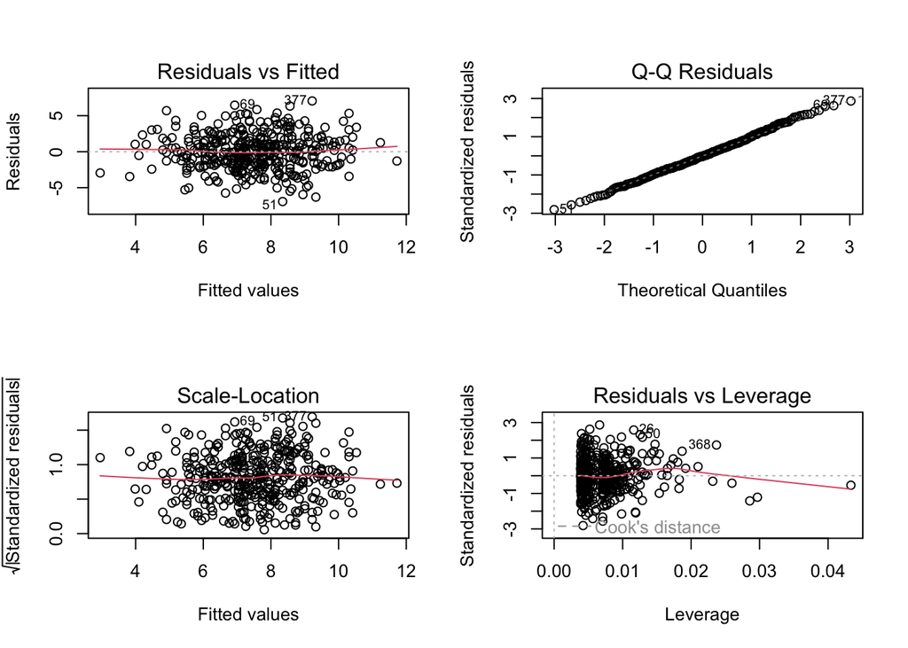

```r
par(mfrow=c(2,2)) # Change the panel layout to 2 x 2
plot(carseat2.model)
```

There do not seem to be any strong outliers in the data, however it does seem that there is an observation that is causing high leverage in the model based on the Residuals vs Leverage plot.

# Question 12:

### This problem involves simple linear regression without an intercept.

### 12.(a) Recall that the coefficient estimate βˆ for the linear regression of Y onto X without an intercept is given by (3.38). Under what circumstance is the coefficient estimate for the regression of X onto Y the same as the coefficient estimate for the regression of Y onto X?

X onto Y:

β̂=∑<sub>i</sub>x<sub>i</sub>y<sub>i</sub> / ∑<sub>j</sub>y<sup>2</sup><sub>j</sub>

Y onto X:

β̂=∑<sub>i</sub>x<sub>i</sub>y<sub>i</sub> / ∑<sub>j</sub>x<sup>2</sup><sub>j</sub>

### 12.(b) Generate an example in R with n = 100 observations in which the coefficient estimate for the regression of X onto Y is different from the coefficient estimate for the regression of Y onto X.

```r
x = rnorm(100)
y = rbinom(100,2,0.3)
estiReg <- lm(y~x+0)
summary(estiReg)
```

```
##
## Call:
## lm(formula = y ~ x + 0)
##
## Residuals:
##      Min       1Q   Median       3Q      Max
## -0.18300  0.02035  0.83044  1.05747  2.13703
##
## Coefficients:
##   Estimate Std. Error t value Pr(>|t|)
## x  0.09892    0.10030   0.986    0.326
##
## Residual standard error: 0.9697 on 99 degrees of freedom
## Multiple R-squared:  0.00973,    Adjusted R-squared:  -0.0002731
## F-statistic: 0.9727 on 1 and 99 DF,  p-value: 0.3264
```

```r
estiReg2 <- lm(x~y+0)
summary(estiReg2)
```

```
##
## Call:
## lm(formula = x ~ y + 0)
##
## Residuals:
##     Min      1Q  Median      3Q     Max
## -2.4497 -0.6794 -0.1926  0.4977  2.3449
##
## Coefficients:
##   Estimate Std. Error t value Pr(>|t|)
## y  0.09836    0.09973   0.986    0.326
##
## Residual standard error: 0.9669 on 99 degrees of freedom
## Multiple R-squared:  0.00973,    Adjusted R-squared:  -0.0002731
## F-statistic: 0.9727 on 1 and 99 DF,  p-value: 0.3264
```

### 12.(c) Generate an example in R with n = 100 observations in which the coefficient estimate for the regression of X onto Y is the same as the coefficient estimate for the regression of Y onto X.

```r
x = 1:100
y = 100:1
estiReg3 <- lm(y~x+0)
summary(estiReg3)
```

```
##
## Call:
## lm(formula = y ~ x + 0)
##
## Residuals:
##    Min     1Q Median     3Q    Max
## -49.75 -12.44  24.87  62.18  99.49
##
## Coefficients:
##   Estimate Std. Error t value Pr(>|t|)
## x   0.5075     0.0866    5.86 6.09e-08 ***
## ---
## Signif. codes:  0 '***' 0.001 '**' 0.01 '*' 0.05 '.' 0.1 ' ' 1
##
## Residual standard error: 50.37 on 99 degrees of freedom
## Multiple R-squared:  0.2575, Adjusted R-squared:   0.25
## F-statistic: 34.34 on 1 and 99 DF,  p-value: 6.094e-08
```

```r
estiReg4 <- lm(x~y+0)
summary(estiReg4)
```

```
##
## Call:
## lm(formula = x ~ y + 0)
##
## Residuals:
##    Min     1Q Median     3Q    Max
## -49.75 -12.44  24.87  62.18  99.49
##
## Coefficients:
##   Estimate Std. Error t value Pr(>|t|)
## y   0.5075     0.0866    5.86 6.09e-08 ***
## ---
## Signif. codes:  0 '***' 0.001 '**' 0.01 '*' 0.05 '.' 0.1 ' ' 1
##
## Residual standard error: 50.37 on 99 degrees of freedom
## Multiple R-squared:  0.2575, Adjusted R-squared:   0.25
## F-statistic: 34.34 on 1 and 99 DF,  p-value: 6.094e-08
```